# [Stories from the Archives](https://blogs.archives.qld.gov.au/)

## Queensland State Archives

# The Not-So-Great-Escape

[26 April, 2016](https://blogs.archives.qld.gov.au/2016/04/26/the-not-so-great-escape/) By [Queensland State Archives](https://blogs.archives.qld.gov.au/author/qsarchives/)

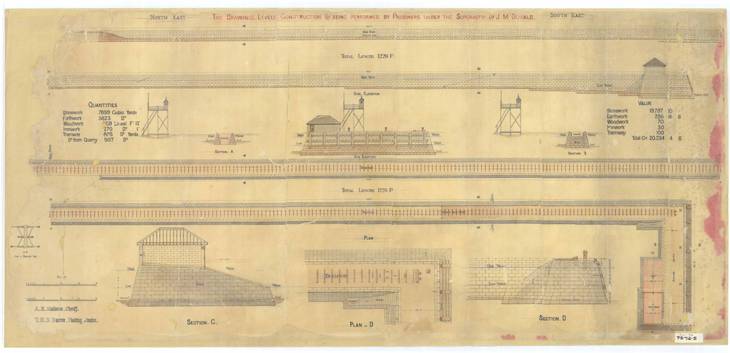

Within our collection are a thousand different stories, heroic wartime efforts, political turmoil and pioneering outback existence. Today we wanted to share the tale of an attempted prison escape detailed in a letter from our collection dated 20 January 1932.

[figure not shown]

Max Paul Rank Runkel and John Edward Phillips were prisoners serving time at the prison farm located on St Helena. The Queensland Corrective Services (QCS) [website](http://bit.ly/1Mx0VDS) describes that, though not declared a penal settlement in 1867, the island was first used as a prison in 1826 by Commandant Patrick Logan. Commandant Logan was faced with the troublesome behaviour of an Indigenous prisoner known as ‘Napoleon’ who was serving his sentence at Dunwich gaol on Stradbroke Island. To solve this problem, Logan decided to relocate Napoleon, dumping the prisoner on the then unnamed island.

It would be the island’s first resident that inspired its name, for Napoleon Bonaparte, the famous French military commander and erstwhile Emperor, was at the time exiled on a remote island off the coast of South America, called St Helena Island. It wasn’t long before “the Officer in Charge of the Branch Penal Settlement at Dunwich named [the island] [St Helena](https://en.wikipedia.org/wiki/St_Helena_Island_National_Park)”

The Prison grew from this inauspicious beginning, and by 1866 a quarantine station was established, with prisoners from the prison hulk *Prosperine* commuting daily to clear scrubland, sink wells and build the jetty. The island was declared a penal establishment on the 14 May 1867 with the intention of housing long-term prisoners who would be kept busy with labouring on the land. As noted by QCS some ideas didn’t quite go to plan:

“At first, prisoners were set to work growing sugar cane, however the cane provided too many hiding places so it was replaced by lucerne and potatoes.”

So what of Runkel and Phillips’ daring escape?

The letter reports that another prisoner, Frank Gale, had complained on the 18 January 1932 that timber he had selected for his work detail had disappeared. A search was made of the ‘old carpenter’s shop’ and ‘five boards cut to shape and suitable for making the flooring for the bow end of a boat’ were discovered. The Deputy Superintendent of the Prison identifies Runkel and Phillips as being the likely suspects due to them being ‘the only two prisoners […] that have access to carpenter’s tools.’

A search of the island is conducted, with reports from the prison staff that both Max and John had been seen out of bounds within nearby mangroves. As reported by the Deputy Superintendent:

‘I met Temporary Warder Boatman Davies and received his report. He stated that after searching the mangroves for about ten minutes, he saw two men carrying timber along the foreshore, coming in his direction. He too up a position behind a clump of small mangrove bushes and waited. Prisoners Phillips and Runkel passed within 25 feet of his hiding place each carrying a board about 6’ x 2’6”. He did not stop them, intending to locate their destination. He states that he found it very difficult to follow as he had to keep well in the mangroves to avoid being seen. He eventually lost sight of them but followed their tracks until he lost those also …’

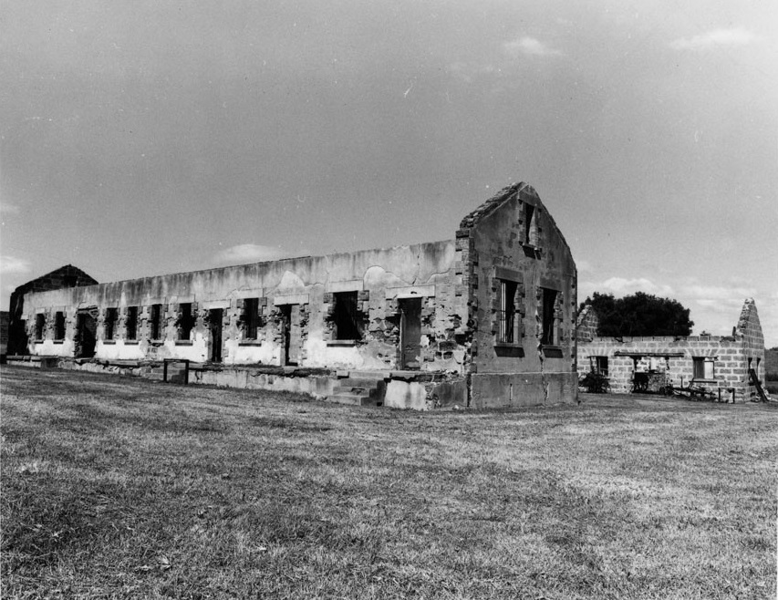

Buildings on St Helena Island, c 1986

The next day the Deputy Superintendent takes action, transferring Phillips, Runkel and four other suspected accomplices to Brisbane Prison ‘on suspicion of being implicated in the making of a boat to escape.’

That evening the prison staff conducted a further search of the mangroves, discovering:

‘The bottom of a flat-bottomed centre board boat the size of which was 17’ x 6’. This had been just fitted with new sides. Found underneath were pieces of timber tongue and grooved and nailed together awaiting attachment. This discovery was secreted in a thick patch of mangroves 250 yards from the foreshore and at the rear of the Official Quarters.’

But what of Runkel and Phillips?

[figure not shown]

Letter – 26 January 1932

A letter within the collection dated the 26 January 1932 details that both were charged with Disobedience of Orders by being out of bounds, and with possessing an unauthorised article regarding the timber. Both prisoners pleaded guilty to the first charge, Runkel receiving a sentence of four days of half rations. Phillips was given a more severe punishment, being sentenced to one month hard labour to be added onto the end of his current sentence.

As to the second charge both pleaded innocent. Yet the Visiting Justice deemed that both men were guilty, adding a further extension to their sentences of one month of hard labour.

The reality is that for all their ambition Runkel and Phillips had the odds firmly stacked against them, for during the prison’s 65 year history only three escape attempts had ever succeeded.

Indeed if a return to the mainland was what they desired, Runkel and Phillips needed only to wait, for that very same year, in December 1932, St Helena prison was closed for good.

Want to find out more about the prisoners at St Helena? Search the index for all prisoners held at St Helena from [1863- 1936](http://www.archives.qld.gov.au/Researchers/Indexes/Convicts/Pages/StHelena.aspx)

### About Queensland State Archives

For more information about Queensland State Archives visit www.archives.qld.gov.au.

### 4 Responses

1. **Anonymous**

   Thanks for this important record of our history
   1. **[Queensland State Archives](http://blogs.archives.qld.gov.au/)**

      You’re more than welcome – we’re glad you enjoyed it.
2. **Will**

   Who at the time was the deputy Superintendent
3. **[Macey](http://outlook/)**

   Omg this information was suburb thanks.

### Leave a Reply

Comment *

Name

Email

Website

## Subscribe to QSA

The text of our blog posts is available under a [Creative Commons Attribution 3.0 Australia (CC BY 3.0) licence](https://creativecommons.org/licenses/by/3.0/au/).

Search for: